# Read and combine .nc files

Eric R. Scott

2021-11-10

*Last compiled: 2021-11-12*

# 1 Purpose

For each CMIP6 model, I want a tibble with a single value for each climate variable for each month. These values should be an average of a 3x3 grid cell area with my study site (Biological Dynamics of Forest Fragments Project, BDFFP) roughly at its center.

The center of BDFFP is at about -2.41ºN, -59.83ºE

# 2 Read in files

`read_stars()` automatically combines .nc files with the same dimensions.

```r
files <- list.files(here("data_raw", "ssp126", "MRI-ESM2-0"), full.names = TRUE)
x <- read_stars(files, proxy = TRUE)
```

[output not shown]

```r
#proxy = TRUE means it only reads metadata.  Doesn't read in files until calculations are performed.

#set coordinate reference system?  CMIP documentation say it's WGS84
#From James Michielini:
st_crs(x) <- "+proj=longlat +datum=WGS84 +no_defs +ellps=WGS84 +towgs84=0,0,0"

x
```

```
## stars_proxy object with 6 attributes in 6 file(s):
## $`hfls_ssp126_MRI-ESM2-0_2015-01-01_2100-12-01.nc`
## [1] "[...]/hfls_ssp126_MRI-ESM2-0_2015-01-01_2100-12-01.nc"
##
## $`hfss_ssp126_MRI-ESM2-0_2015-01-01_2100-12-01.nc`
## [1] "[...]/hfss_ssp126_MRI-ESM2-0_2015-01-01_2100-12-01.nc"
##
## $`pr_ssp126_MRI-ESM2-0_2015-01-01_2100-12-01.nc`
## [1] "[...]/pr_ssp126_MRI-ESM2-0_2015-01-01_2100-12-01.nc"
##
## $`tas_ssp126_MRI-ESM2-0_2015-01-01_2100-12-01.nc`
## [1] "[...]/tas_ssp126_MRI-ESM2-0_2015-01-01_2100-12-01.nc"
##
## $`tasmax_ssp126_MRI-ESM2-0_2015-01-01_2100-12-01.nc`
## [1] "[...]/tasmax_ssp126_MRI-ESM2-0_2015-01-01_2100-12-01.nc"
##
## $`tasmin_ssp126_MRI-ESM2-0_2015-01-01_2100-12-01.nc`
## [1] "[...]/tasmin_ssp126_MRI-ESM2-0_2015-01-01_2100-12-01.nc"
##
## dimension(s):
##      from   to  offset    delta                       refsys point
## x       1  320 -0.5625    1.125 +proj=longlat +datum=WGS8...    NA
## y       1  160 89.7022 -1.12128 +proj=longlat +datum=WGS8...    NA
## time    1 1032      NA       NA                      POSIXct    NA
##                                           values x/y
## x                                           NULL [x]
## y                                           NULL [y]
## time 2015-01-16 12:00:00,...,2100-12-16 12:00:00
```

So, there’s a bunch of warnings from GDAL, but I don’t know what they mean.

# 3 Fix the variable names

For some reason the variable names are the file names?? I’ll just extract the first part, which is the variable.

```r
names(x) <- str_extract(names(x), "^[:alpha:]+(?=_)")
```

# 4 Crop

I’m trying to understand WHY the dimensions are like they are.

```r
st_dimensions(x)
```

```
##      from   to  offset    delta                       refsys point
## x       1  320 -0.5625    1.125 +proj=longlat +datum=WGS8...    NA
## y       1  160 89.7022 -1.12128 +proj=longlat +datum=WGS8...    NA
## time    1 1032      NA       NA                      POSIXct    NA
##                                           values x/y
## x                                           NULL [x]
## y                                           NULL [y]
## time 2015-01-16 12:00:00,...,2100-12-16 12:00:00
```

```r
st_get_dimension_values(x, which = "x", where = "center") %>% max()
```

```
## [1] 358.875
```

```r
st_get_dimension_values(x, which = "x", where = "start") %>% max()
```

```
## [1] 358.3125
```

```r
st_get_dimension_values(x, which = "x", where = "end") %>% max()
```

```
## [1] 359.4375
```

```r
359.4375 + 0.5625
```

```
## [1] 360
```

Ok, so first pixel is *centered* at 0, so last pixel ends where first pixel begins (-0.5626 = 359.4375), and that does total 360º, even though the “last” pixel actually ends at 359.4375.

Is it worthwhile to try to change the coordinates to just normal decimal degrees or whatever? -59.83ºE is just 360-59.83 = 300.17, yeah? Or is it 358.875 - 59.83?

## 4.1 What pixel contains the center of BDFFP?

So, I’m sure there is a “spatial stats” way to do this by, like, creating a `sf` object of a point, and then asking where that point intersects my raster, but I’m going to do this the dumb way for now.

```r
lon_pixels_cen <- st_get_dimension_values(x, which = "x", where = "center")
lon_pixels_start <- st_get_dimension_values(x, which = "x", where = "start")
lon_pixels_end <- st_get_dimension_values(x, which = "x", where = "end")
# using the start of the pixels because I don't know why.  I did some trial and error stuff and this worked?
lon_dist <- lon_pixels_start - (359.4375-59.83)
which.min(abs(lon_dist))
```

```
## [1] 268
```

```r
# pixel 268 in the lon dimension contains BDFFP
lon_pixels_start[which.min(abs(lon_dist))] - 359.4375
```

```
## [1] -59.625
```

```r
lon_pixels_end[which.min(abs(lon_dist))] -359.4375
```

```
## [1] -58.5
```

```r
lat_pixels_cen <- st_get_dimension_values(x, which = "y", where = "center")
lat_pixels_start <- st_get_dimension_values(x, which = "y", where = "start")
lat_pixels_end <- st_get_dimension_values(x, which = "y", where = "end")
lat_dist <- lat_pixels_start - (-2.41)
which.min(abs(lat_dist))
```

```
## [1] 83
```

```r
# pixel 83 in the lat dimension
lat_pixels_start[which.min(abs(lat_dist))]
```

```
## [1] -2.242554
```

```r
lat_pixels_end[which.min(abs(lat_dist))]
```

```
## [1] -3.363831
```

So BDFFP is in pixel [268, 83]

## 4.2 Bounding box method

Find the pixel that encompass the center of BDFFP and get an area 3x3 around it (i.e. with BDFFP in the center pixel)

```r
lat_cen <- which.min(abs(lat_dist))
lon_cen <- which.min(abs(lon_dist))

d = st_dimensions(x)
offset = c(d[["x"]]$offset, d[["y"]]$offset)
res = c(d[["x"]]$delta, d[["y"]]$delta)

# Convert to degrees using this formula
offset[1] + lon_cen * res[1]
```

```
## [1] 300.9375
```

```r
offset[2] + lat_cen * res[2]
```

```
## [1] -3.363831
```

```r
bb = st_bbox(c( #I did this sort of by trial and error.  I don't really understand.
  xmin = offset[1] + (lon_cen-2) * res[1],
    ymin = offset[2] + (lat_cen+1) * res[2],
    xmax = offset[1] + (lon_cen+1) * res[1],
    ymax = offset[2] + (lat_cen-2) * res[2]
  ), crs = st_crs(x))
```

## 4.3 Plot bounding box

```r
x_slice <- slice(x, index = 1, along = time) #take just first year

brazil <-
  raster::getData("GADM", country = "BRA", level = 1, path = here("cache_data")) %>%
  st_as_sf() #get brazil borders

amazonas <-
  brazil %>%
  filter(NAME_1 == "Amazonas") #the state BDFFP is in

#crop my raster to just what's in Amazonas, Brazil
x_brazil <-
  st_crop(x_slice, amazonas) %>%
  st_as_stars()
```

[output not shown]

There’s those GDAL warnings again.

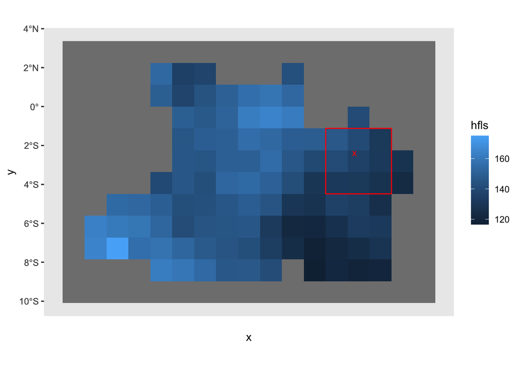

```r
p <-
  ggplot() +
  geom_stars(data = x_brazil) +
  geom_sf(data = st_as_sfc(bb), fill = NA, color = "red") +
  annotate(
    geom = "point",
    x = 360-59.8333,
    y = -2.41,
    shape = "x",
    size = 3,
    color = "red"
  ) +
  # geom_sf(data = amazonas) + #doesn't work because different coordinate systems I think
  coord_sf()
p
```

So bounding box looks right! The x-axis doesn’t show up because `coord_sf()` is not expecting 0–360º, I think.

There are two ways to use this bounding box, I think.

1. Just crop the pixels, then convert to tibble and aggregate using familiar tidyverse methods:

```r
library(tictoc) #for benchmarking, run entire chunk from tic() to toc() to get time.
tic()
x_cropped <- x[bb]
x_tbl <- x_cropped %>%
  st_as_stars() %>%  #converts to in RAM object
  as_tibble() %>% #converts to tibble
  group_by(time) %>%  #for each time step
  summarize(across(c(hfls, hfss, pr, tas, tasmax, tasmin), mean))
toc()
```

```
## 20.997 sec elapsed
```

```r
head(x_tbl)
```

```
## # A tibble: 6 × 7
##   time                   hfls    hfss         pr   tas tasmax tasmin
##   <dttm>              [W/m^2] [W/m^2] [kg/m^2/s]   [K]    [K]    [K]
## 1 2015-01-16 12:00:00    135.   24.3   0.0000873  300.   303.   297.
## 2 2015-02-15 00:00:00    139.   15.1   0.000164   300.   302.   298.
## 3 2015-03-16 12:00:00    141.   14.1   0.000152   300.   303.   298.
## 4 2015-04-16 00:00:00    148.    8.38  0.000202   300.   302.   298.
## 5 2015-05-16 12:00:00    138.   12.3   0.000143   299.   302.   297.
## 6 2015-06-16 00:00:00    128.   23.0   0.0000484  299.   303.   297.
```

Quite slow, but transparent.

2. Use the `aggregate()` function from `stars` to take a mean, spatially.

```r
tic()
x_tbl2 <-
  aggregate(x, st_as_sfc(bb), FUN = mean, join = st_intersects) %>%
  as_tibble()
toc()
```

```
## 8.943 sec elapsed
```

```r
head(x_tbl2)
```

```
## # A tibble: 6 × 8
##                    geometry time                 hfls  hfss      pr   tas tasmax
##               <POLYGON [°]> <dttm>              <dbl> <dbl>   <dbl> <dbl>  <dbl>
## 1 ((298.6875 -4.485108, 30… 2015-01-16 12:00:00  135. 24.3  8.73e-5  300.   303.
## 2 ((298.6875 -4.485108, 30… 2015-02-15 00:00:00  139. 15.1  1.64e-4  300.   302.
## 3 ((298.6875 -4.485108, 30… 2015-03-16 12:00:00  141. 14.1  1.52e-4  300.   303.
## 4 ((298.6875 -4.485108, 30… 2015-04-16 00:00:00  148.  8.38 2.02e-4  300.   302.
## 5 ((298.6875 -4.485108, 30… 2015-05-16 12:00:00  138. 12.3  1.43e-4  299.   302.
## 6 ((298.6875 -4.485108, 30… 2015-06-16 00:00:00  128. 23.0  4.84e-5  299.   303.
## # … with 1 more variable: tasmin <dbl>
```

About twice as fast. Doesn’t keep units like the cropping method.

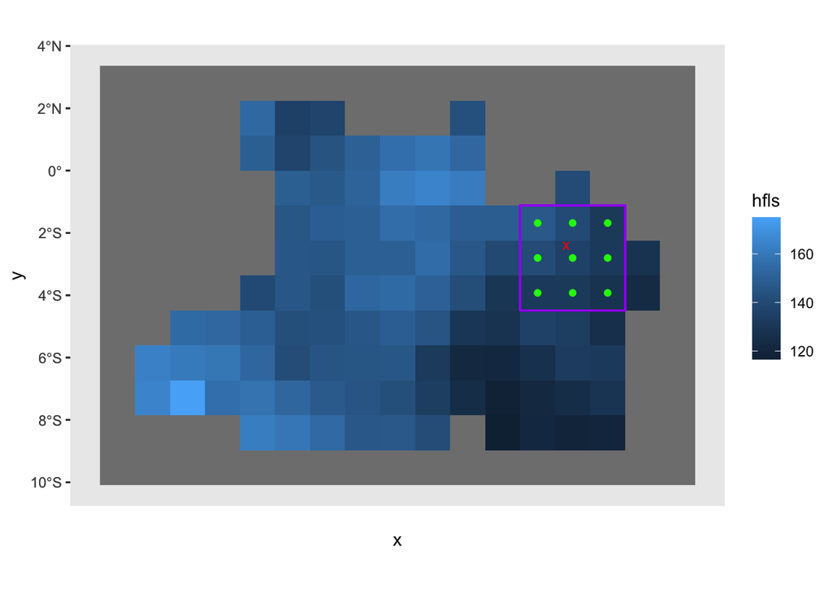

```r
p +
  geom_sf(data = st_as_sfc(x_cropped, as_points = TRUE), fill = NA, color = "green") +
  geom_sf(data = x_tbl2, aes(geometry = geometry), fill = NA, color = "purple")
```

x marks the rough center of BDFFP, green dots mark the pixels selected by cropping with `[` and the purple box marks the area that `aggregate()` averaged over.

```r
all.equal(as.numeric(x_tbl$hfls), x_tbl2$hfls)
```

```
## [1] TRUE
```

Both methods calculate the same data, so that’s good.

# 5 With data across multiple files

I think I need to read in each variable separately, then aggregate stars objects to create separate attributes for each variable.

```r
idx <- read_csv(here("data_raw", "metadata", "idx_ssp126.csv"))
EC_earth_files <-
  idx %>%
  filter(source_id == "EC-Earth3") %>%
  group_by(variable_id) %>%
  select(download_path) %>%
  group_split()
```

```r
EC_stars_list <-
  EC_earth_files %>%
  map(~{
    read_stars(.x$download_path) %>% set_names(.x$variable_id[1])
  })
```

[output not shown]

[output cut: 4072 more lines]

[output not shown]

```r
EC_stars <- do.call(c, EC_stars_list)
```

This pattern should work for models with fewer files too, so this should be the function to write.